# SAVOR: Part IV

- Show All Code
- Hide All Code

`ggplot2`

Author

Robin Genuer & Boris Hejblum

Published

June 12, 2026

# Introduction

Ce document donne quelques éléments introductifs sur l’utilisation du package `ggplot2`.

## Le package `ggplot2`

`ggplot2` est un package de très utilisé pour tracer des graphiques sur R. La syntaxe est différente des fonctions graphiques de base, mais s’avère très puissante en pratique. Une très bonne référence pour commencer à utiliser ce package se trouve [ici](http://www.cookbook-r.com/Graphs/). L’[aide en ligne](http://docs.ggplot2.org/current/) est plus complète (mais très fournie). On pourra également se reporter à cet [aide-mémoire](https://rstudio.github.io/cheatsheets/data-visualization.pdf)

Installer le package puis le charger.

```r
# install.packages("ggplot2")
library(ggplot2)
```

Importer ensuite le jeu de données `naissance.txt` documentant le poids à la naissance de 189 nouveaux-nés en fonctions d’un certains nombres de variable (dont l’âge de la mère, son poids ainsi que l’historique d’hypertension), puis transformer la variable `SMOKE` pour illustrer le codage “Non-Fumeur” (codé `0`) et “Fumeur” (codé `1`), ainsi que la variable `HT` codée “Non” (`0`) et “Oui” (`1`).

```r
naissance <- read.delim("../Data/naissance.txt")
naissance <- transform(naissance,
    SMOKE = factor(SMOKE, labels = c("Non-Fumeur", "Fumeur")),
    HT = factor(HT, labels = c("Non", "Oui")))
str(naissance)
```

```
## 'data.frame':    189 obs. of  10 variables:
##  $ ID   : int  85 86 87 88 89 91 92 93 94 95 ...
##  $ AGE  : int  19 33 20 21 18 21 22 17 29 26 ...
##  $ LWT  : int  182 155 105 108 107 124 118 103 123 113 ...
##  $ RACE : int  2 3 1 1 1 3 1 3 1 1 ...
##  $ SMOKE: Factor w/ 2 levels "Non-Fumeur","Fumeur": 1 1 2 2 2 1 1 1 2 2 ...
##  $ PTL  : int  0 0 0 0 0 0 0 0 0 0 ...
##  $ HT   : Factor w/ 2 levels "Non","Oui": 1 1 1 1 1 1 1 1 1 1 ...
##  $ UI   : int  1 0 0 1 1 0 0 0 0 0 ...
##  $ FVT  : int  0 3 1 2 0 0 1 1 1 0 ...
##  $ BWT  : int  2523 2551 2557 2594 2600 2622 2637 2637 2663 2665 ...
```

## La fonction `ggplot()`

`ggplot2` fonctionne par un système de couches (“layers”). Ce système permet de rajouter des couches avec `+`.

La fonction principale du package `ggplot2` est la fonction `ggplot()`. À cette fonction, qui a pour but de spécifier et de préparer les données pour le graphique, on ajoute donc des couches grâce aux fonctions `geom_...()`, qui vont spécifier le type de graphique à afficher (par exemple `geom_point()` ou `geom_bar()`).

De plus, `ggplot2` permet de rajouter des couches à des graphiques déjà existants sauvegardés dans des objets. C’est un comportement très différent de la gestion des graphiques comparé au `R` de base.

# Nuage de points

### Exercice 1 :

1. Tracer le nuage de point du poids à la naissance (variable `BWT`) en fonction de l’âge (variable `AGE`) grâce à la fonction `geom_point()`.
2. Ajouter une couleur selon le statut tabagique de la mère (`SMOKE`) (*on remarque que la légende se trace automatiquement*).
3. Rajouter une droite de régression avec la fonction `geom_smooth()`.
4. Consulter l’aide de la fonction `geom_smooth()` pour enlever l’intervalle de confiance et tracer la droite en rouge.
5. A l’aide de `geom_hline()`, ajouter une droite horizontale d’ordonnée 2500, bleue et de style “tirets”.
6. Créer un objet `p` qui contient le graphique du nuage de points uniquement comme demandé à la question 1 (taper le nom de l’objet pour vérifier que le graphique a été correctement créé.). Rajouter ensuite la droite de régression en modifiant `p`.
7. Préciser le nom des axes.
8. Ajouter le thème `theme_bw()` afin de se rapprocher d’un style plus classique de graphique.

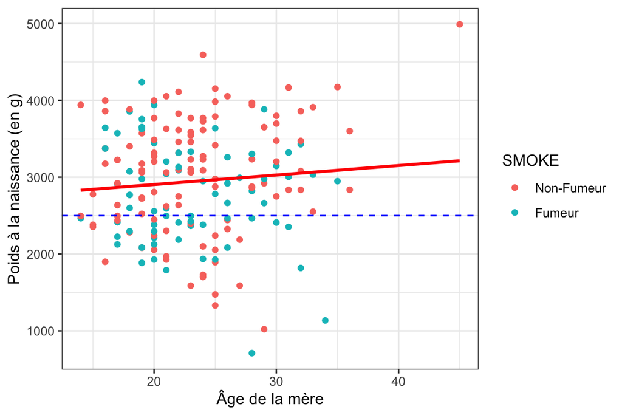

# Stratification

Le package `ggplot2` rend très facile la stratification des représentations selon des groupes définis par une variable catégorielle.

### Exercice 2 :

1. Reproduire le graphique précédent en traçant 2 droites de regression selon le statut tabagique de la mère (en introduisant l’estéthique `group`dans la fonction `aes()` de la fonction `geom_smooth()`).

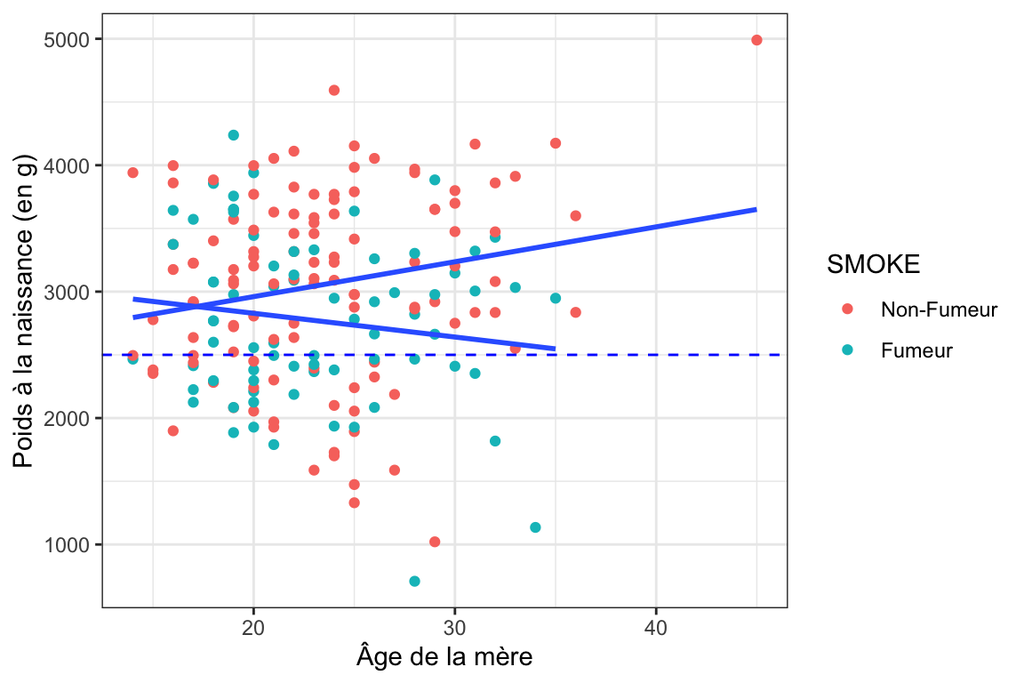

2. Utiliser la fonction `facet_wrap()` pour tracer 2 graphiques distincts.
3. Laisser l’échelle s’adapter à chacun des 2 graphiques.

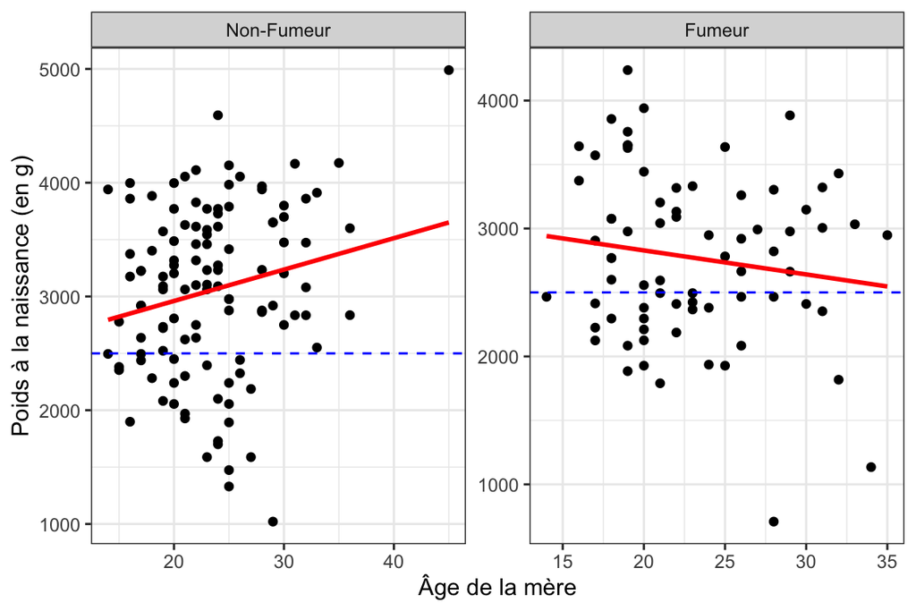

# Autres types de graphiques

### Exercice 3 :

1. Tracer un boxplot du poids du bébé à la naissance (on utilisera `x=""` dans les esthétiques de `geom_boxplot()`).

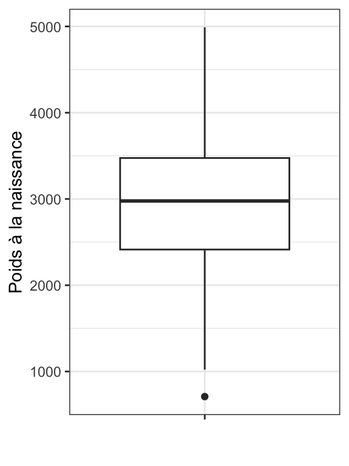

2. Stratifier selon le statut fumeur de la mère (on pourra s’intéresser à l’esthétique `fill`).
3. Ajouter un titre avec la fonction `ggtitle()`.

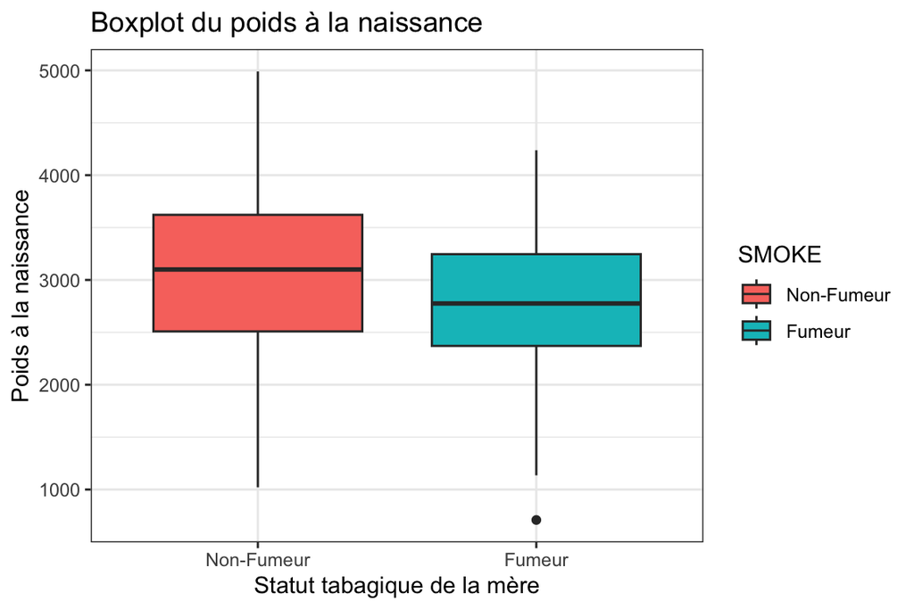

4. Tracer un histogramme du poids à la naissance avec la fonction `geom_histogram()`. Ajouter un contour blanc pour une meilleure lisibilité. Ajouter une ligne verticale indiquant la limite inférieure de 2,5 kg.

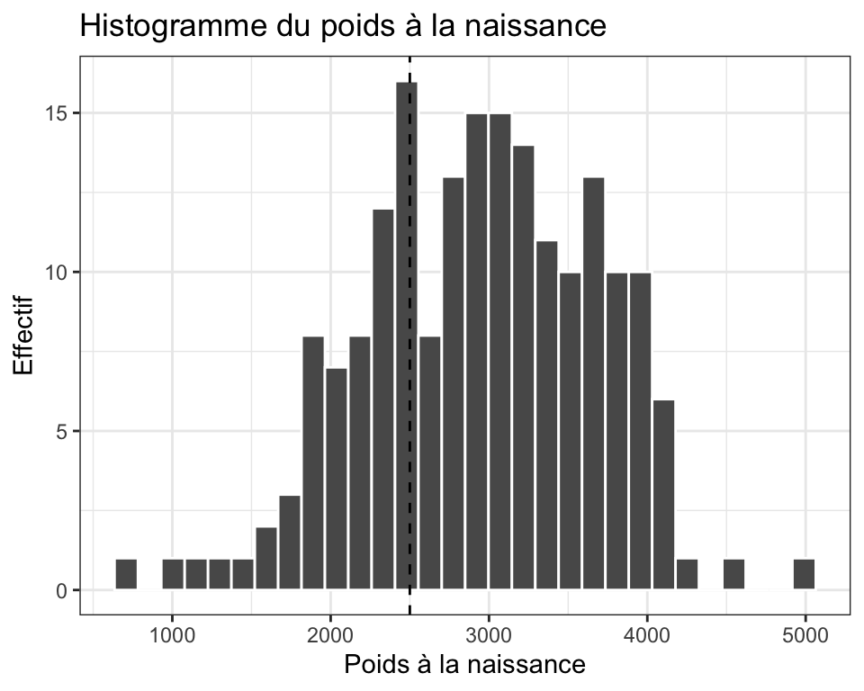

5. Remplir les barres de l’histogramme selon l’historique d’hypertension.
6. Changer le code couleur grâce à la fonction `scale_fill_manual()`.

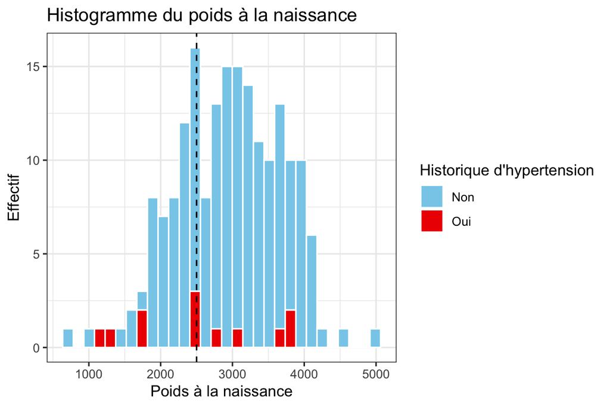

7. Tracer une estimation de la densité de probabilité du poids à la naissance, dans chaque groupe de statut tabagique (sur le même graphique) avec la fonction `geom_density()`.

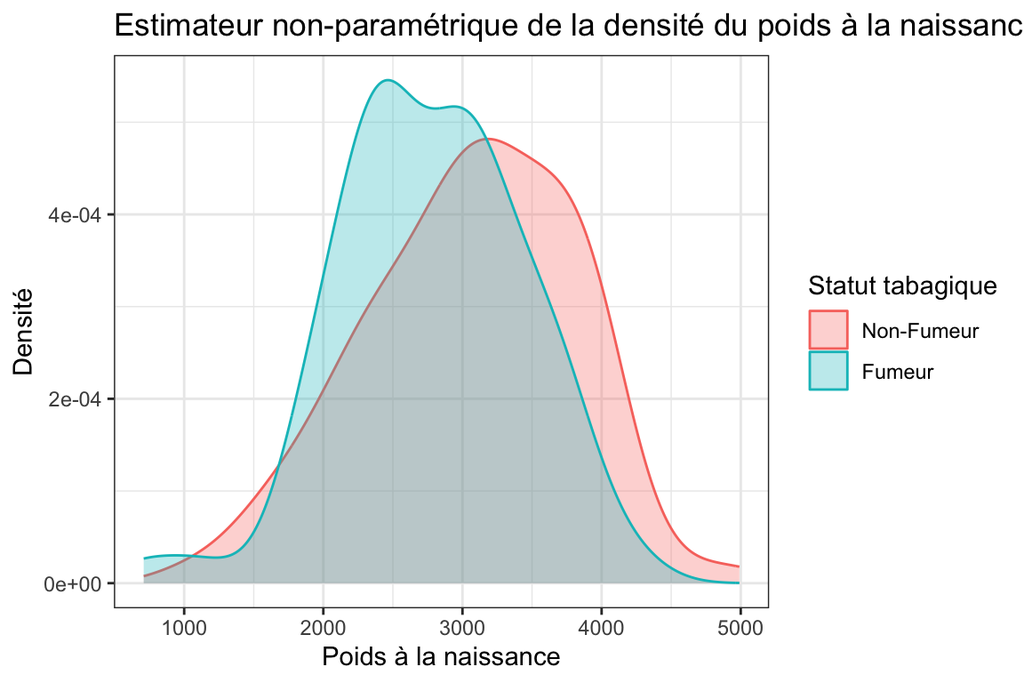

8. Passer à l’échelle logarithmique avec la fonction `scale_x_log10()`.
9. Exporter le graphique au fromat *.png* avec la fonction `ggsave()`, avec une résolution de 300 dpi, puis au format *.eps*.
10. Ajouter une ligne verticale indiquant la limite inférieure de 2,5 kg, puis ajouter une légende pour la ligne verticale.

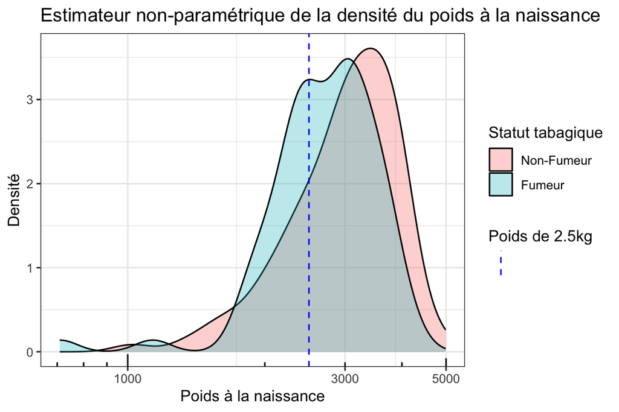

## Exercice 4: `patchwork`

Le package [`patchwork`](https://patchwork.data-imaginist.com/) permet de simplement accoler plusieurs `ggplot`s pour former une seule figure.

```r
library(patchwork)
```

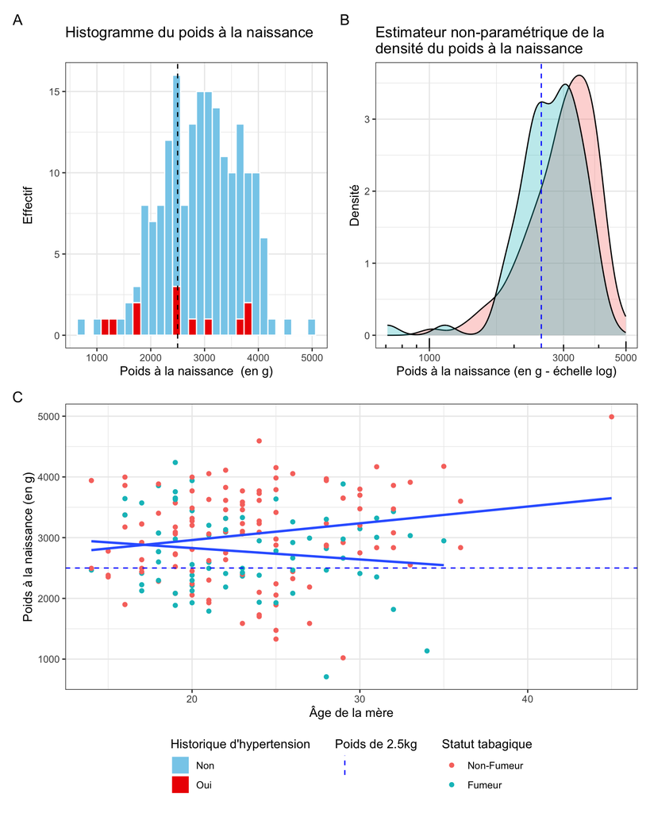

*NB:* D’autres packages comme [`cowplot`](https://cran.r-project.org/web/packages/cowplot/vignettes/introduction.html) ou [`ggpubr`](https://rpkgs.datanovia.com/ggpubr/) servent le même objectifs mais avec une syntaxe plus complexe.

# BONUS: graphiques animés

## Exercice 5: `gganimate`

# Objectif

**Transformer des graphiques statiques en graphiques dynamiques avec le package `gganimate`**

# Pré-requis

## Installation des packages nécessaires

```r
if (!require("gapminder", quietly = TRUE))
    install.packages("gapminder")
if (!require("ggplot2", quietly = TRUE))
    install.packages("ggplot2")
if (!require("gganimate", quietly = TRUE))
    install.packages("gganimate")
if (!require("gifski", quietly = TRUE))
    install.packages("gifski")
if (!require("transformr", quietly = TRUE))
    install.packages("transformr")
if (!require("MetBrewer", quietly = TRUE))
    install.packages("MetBrewer")
if (!require("ggrepel", quietly = TRUE))
    install.packages("ggrepel")
if (!require("dplyr", quietly = TRUE))
    install.packages("dplyr")
```

La documentation de `gganimate` est accessible [ici 👉🌐](https://gganimate.com/)

## Jeu de données

Nous allons utiliser le jeu de données `gapminder` tout au long de ce tutoriel

```
##         country        continent        year         lifeExp
##  Afghanistan:  12   Africa  :624   Min.   :1952   Min.   :23.60
##  Albania    :  12   Americas:300   1st Qu.:1966   1st Qu.:48.20
##  Algeria    :  12   Asia    :396   Median :1980   Median :60.71
##  Angola     :  12   Europe  :360   Mean   :1980   Mean   :59.47
##  Argentina  :  12   Oceania : 24   3rd Qu.:1993   3rd Qu.:70.85
##  Australia  :  12                  Max.   :2007   Max.   :82.60
##  (Other)    :1632
##       pop              gdpPercap
##  Min.   :6.001e+04   Min.   :   241.2
##  1st Qu.:2.794e+06   1st Qu.:  1202.1
##  Median :7.024e+06   Median :  3531.8
##  Mean   :2.960e+07   Mean   :  7215.3
##  3rd Qu.:1.959e+07   3rd Qu.:  9325.5
##  Max.   :1.319e+09   Max.   :113523.1
##
```

# Le “problème” avec les graphiques statiques

👉 TODO n°1 : à l’aide de `ggplot2`, représenter l’espérance de vie selon le PIB.

👉 TODO n°2 : à l’aide de la fonction `scale_size()`, transformer le graphique précédent pour tenir comptede la population totale d’une année spécifique (par exemple 2007).  
*Bonus*: ajouter une 4ème dimension en colorant le graphique par continent.

👉 TODO n°3 : faire un graphique pour visualiser l’espérance de vie en fonction du PIB annuel pour chaque pays.

# Première approche pour des graphiques intéractifs : `transition_time()`

👉 TODO n°4 : suivre l’exemple ci-dessous qui s’appuie sur `gganimate` pour générer un graphique animé en `.gif`.

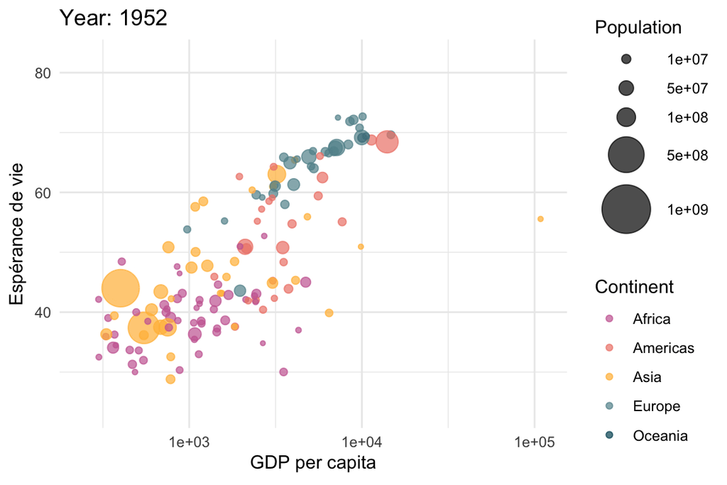

```r
# necessary libraries
library(gganimate)
library(gifski)

p <- ggplot(gapminder, aes(gdpPercap, lifeExp, size = pop, color = continent)) +
  geom_point(alpha = 0.7) +
  scale_x_log10() +
  theme_minimal() +
  # gganimate specific
  labs(title = 'Year: {frame_time}', x = 'GDP per capita', y = 'Espérance de vie') +
  scale_size(name = "Population", breaks = c(10^7, 5*10^7, 10^8, 5*10^8, 10^9, 5*10^9), range=c(1, 15)) +
  scale_color_manual("Continent", values = MetBrewer::met.brewer("Cross", n=5, type = "d")) +
  transition_time(year) +
  ease_aes('linear')
p
```

```r
animate(p, duration = 5, fps = 20, width = 500, height = 500,
        renderer = gifski_renderer())

# Save as a .gif
anim_save("../Results/gganimate1.gif")
```

⚠️ Les graphiques dynamiques ne sont pas seulement réservés aux variations temporelles : ici on peut, par exemple, ajouter chaque continent l’un après l’autre sur le graphique.  
👉 À vous !

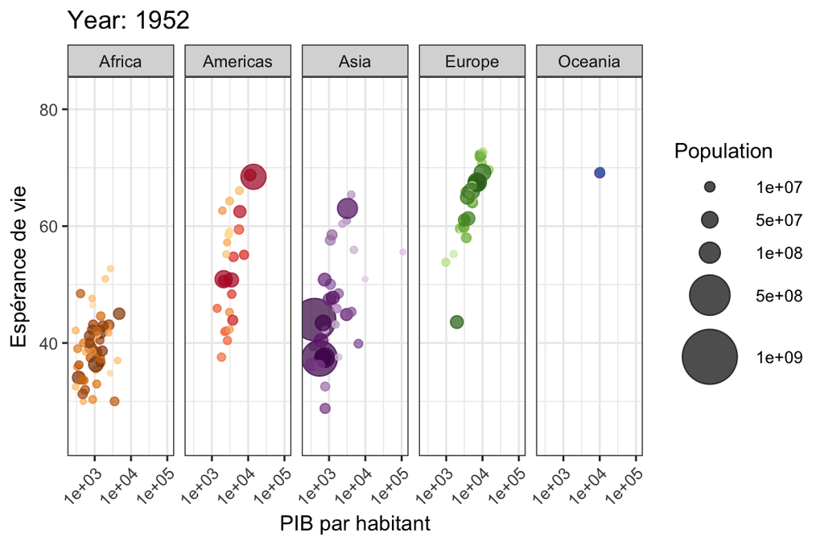

# Gaphique animés avancés : plus de `transitions`

## `transition_layers()`

👉 TODO n°5 : avec `ggplot2`, créer un boxplot de l’espérance de vie par continent

👉 TODO n°5 bis : rendre ce graphique dynamique (démarrer de la médiane et créer une expansion similaire à ce que l’on trouve dans *powerpoint*)

[figure not shown]

## `transition_reveal()`

👉 TODO n°6 : avec `ggplot2`, tracer l’évolution de l’espérance de vie au cours du temps, par continent.

👉 TODO n°6 bis : recommencer, mais avec un graphique animé cette fois.

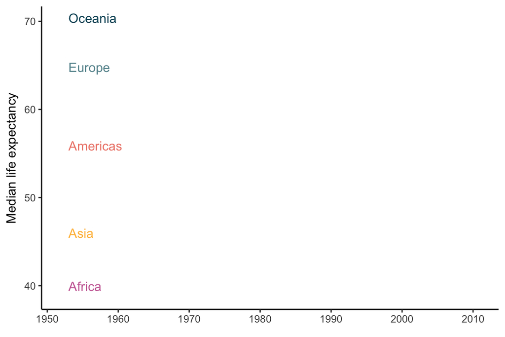

## `transition_states()` & `shadow_mark()`

👉 TODO n°7: représenter la densité de l’espérance de vie mondiale pr année

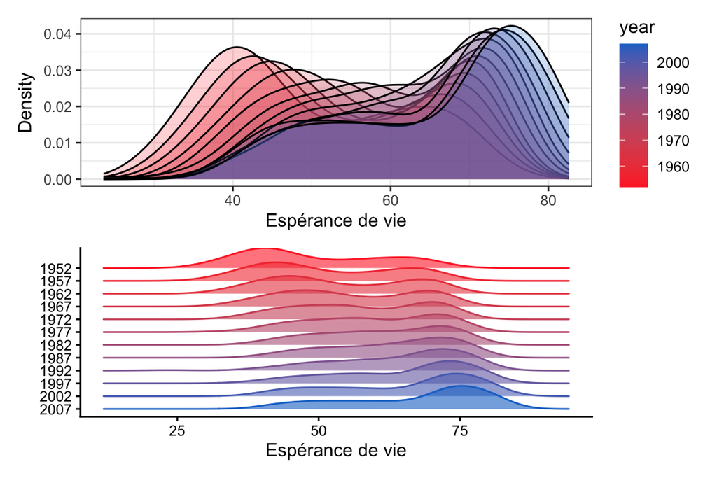

👉 TODO n°7 bis : animer le !

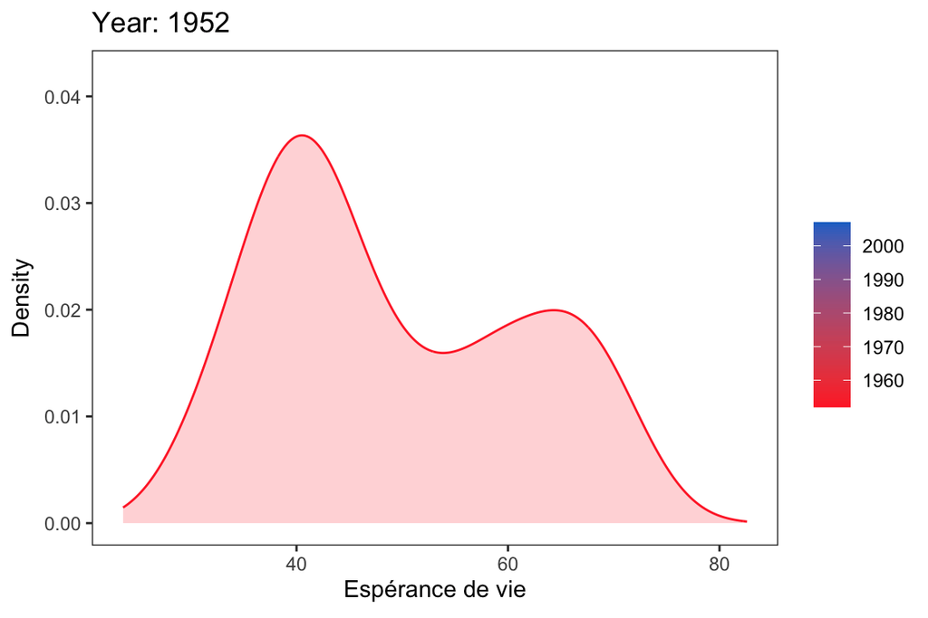

👉 *BONUS du bonus:* Dessine moi un dinosaure (jeter un oeil au package `datasauRus`) !

[figure not shown]